# Clergy Contributions Data Analysis

For my data analysis project, I will be working with Clergy Contributions data from 2018-2024 and the Maryland campaign contributions data.

##Loading libraries

```r
library(tidyverse)
library(lubridate)
library(janitor)
library(ggthemes)
library(tidycensus)
library(ggplot2)
library(ggrepel)
library(tigris)
library(sf)
```

–> Question 1: <- Do the top clergy donors also give to Maryland state campaigns?

##getting the data

The clergy contributions data for 2018-2024 was loaded, along with the Maryland campaign contribution data.

```r
clergy_contribs_2018 <- read_csv("data/clergy_contribs_2018.csv")
clergy_contribs_2020 <- read_csv("data/clergy_contribs_2020.csv")
clergy_contribs_2022 <- read_csv("data/clergy_contribs_2022.csv")
clergy_contribs_2024 <- read_csv("data/clergy_contribs_2024.csv")
md_campaign <- read_csv("~/Downloads/md_contribs.csv.zip")
```

# Cleaning up the clergy contributions data

The clergy contributions data was combined using bind_rows into one dataframe called clergy_contribs_combined. The data was then cleaned, using str_to_upper for majority of the columns within the dataframe and str_sub which created a cutoff of five digits for the zipcodes.

```r
clergy_contribs_combined <- bind_rows(list(clergy_contribs_2018, clergy_contribs_2020, clergy_contribs_2022, clergy_contribs_2024)) |>
  mutate(contributor_first_name = str_to_upper(contributor_first_name), contributor_last_name = str_to_upper(contributor_last_name), contributor_name = str_to_upper(contributor_name), contributor_city = str_to_upper(contributor_city),
         zip5 = str_sub(contributor_zip, start=1L, end=5L))


View(clergy_contribs_combined)
```

In the following code block, I created a new dataframe called clergy_totals, which totaled up the amount of clergy contributions and the number of contributions for each individual within the dataframe. Then, I arranged the data by the total amount so I could find who the top contributors are. The top clergy members that donated to federal campaigns were Doris Cowan with 46760.02 donated, John Price, Michael Freeman, Eldridge Spearman, Rev. Dr. Frank Trotter, Alexa Fraser, Lynette Entzian, Lucretia Mann and David Sword.

```r
clergy_totals <- clergy_contribs_combined |>
  group_by(contributor_name,two_year_transaction_period) |>
  summarize(
    total_amount = sum(contribution_receipt_amount),
    num_contributions = n(),
  ) |>
arrange(desc(total_amount))

clergy_totals
```

| contributor_name | two_year_transaction_period | total_amount | num_contributions |
| --- | --- | --- | --- |
| COWAN, DORIS | 2024 | 46760.02 | 6339 |
| PRICE, JOHN | 2020 | 18724.00 | 294 |
| FREEMAN, MICHAEL ERIN | 2024 | 16600.00 | 6 |
| SPEARMAN, ELDRIDGE | 2020 | 15500.00 | 98 |
| PRICE, JOHN | 2022 | 14582.50 | 241 |
| TROTTER, REV. DR. FRANK | 2024 | 13173.25 | 799 |
| FRASER, ALEXA | 2022 | 10006.61 | 164 |
| ENTZIAN, LYNETTE | 2024 | 10000.00 | 3 |
| MANN, LUCRETIA | 2024 | 9665.57 | 525 |
| SWORD, DAVID | 2024 | 9500.00 | 7 |

[output cut: 990 more lines]

## Searching for the top donors in the md_campaign database

To answer my question, it was important to find the top contributors listed in the clergy_totals dataframe in the Maryland campaign contributions dataframe. To do this, I created dataframes for some of the top contributors, filtering the md_camaign dataframe for their first and last name. This allowed me to see which top contributors also contributed to Maryland campaigns, if at all, and by how much. The majority of the clergy members that contributed federally also contributed to Maryland campaigns; however, there was a clear outlier in the results: Doris Cowan.

```r
d_cowan_state <- md_campaign |>
  filter(contributor_first_name == "DORIS", contributor_last_name == "COWAN")

j_price <- md_campaign |>
  filter(contributor_first_name == "JOHN", contributor_last_name == "PRICE")

a_fraser <- md_campaign |>
  filter(contributor_first_name == "ALEXA", contributor_last_name == "FRASER")

d_sword <- md_campaign |>
  filter(contributor_first_name == "DAVID", contributor_last_name == "SWORD")

l_mann <- md_campaign |>
  filter(contributor_first_name == "LUCRETIA", contributor_last_name == "MANN")

e_spearman <- md_campaign |>
  filter(contributor_first_name == "ELDRIDGE", contributor_last_name == "SPEARMAN")
```

## Explanation from data analysis submission 2

Of the top ten clergy members, the majority of them appear in the Maryland campaigns data frame. Many of the clergy that have contributed to Maryland campaigns have only contributed one time compared to the several contributions made in the clergy data frame. One of the most significant donors in this data is from Doris Cowan, who contributed over 6,000 times in the clergy database, and 25 times in the Maryland campaign data. According to a document from the General Commissioners From Presbytery of Baltimore in 2020, Cowan is honorably retired. Looking at all of the contributions made in the clergy contributions data and the Maryland campaign data, Cowan has contributed money to democratic organizations and campaigns. In comparison to Doris Cowan, the other contributors have only contributed once or twice, such as Alexa Fraser, who contributed twice this year. I think Doris Cowan is an obvious outlier in the data of Maryland campaign contributions. Since they are a retired clergy member, this could indicate that they have signed up for recurring payments unknowingly, or they are just more politically active following retirement.

An interesting factor is that some of these members have only contributed to campaigns within the last few years, 2024-2026, which could possibly suggest that these clergy members are becoming more politically active as the nation becomes increasingly politically polarized.

Since Cowan is the only clergy member that seems to be highly active within the md_campaign dataframe and the clergy contributions dataframe, I decided to focus on them for my data exploration. I am specifically interested in comparing the total amount of contributions given between the federal and state level.

# Creating Cowan dataframes for state and federal contributions + making a bar chart

In the following code section, I cleaned the d_cowan_state dataframe by creating a new column that included the first and last name of the contributor, then renamed the transaction amount and transaction date to match what the columns are in the md_campaign dataframe. Both of these steps are in order for me to later join the federal and state contributions made by Doris Cowan.

```r
d_cowan_state <- d_cowan_state |>
  mutate(contributor_name = paste(contributor_last_name, contributor_first_name, sep = ", ")) |>
  rename(contribution_receipt_amount = transaction_amount,
         contribution_receipt_date = transaction_date)
```

# Creating the federal contributions dataframe for Cowan + combining the Cowan dataframes

For the bar chart, I asked ChatGPT two different things:

When I included the title for my graph, it went off of the page, so I asked ChatGPT if there was a way to adust the size of the title. “Using R and ggplot, I created a bar chart, which includes labs like a title; however, my title is cut off. Is there a way using this library to decrease the font size of my title so it fits in the graph?”

Then, I felt the graph would be more comprehensible if I added the values of each bar.

“Using R and ggplot, I have created a bar chart that shows two values being compared to each other. At the moment, the bar chart does not make much sense without the specific values shown on the graph. Is there a way to include labels for the values and put them inside the bars?”

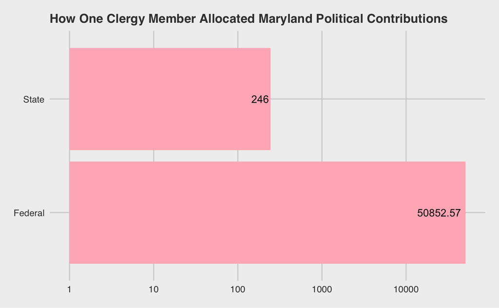

```r
cowan_federal <- clergy_contribs_combined |>
  filter(contributor_name == "COWAN, DORIS") |>
  select(contributor_name, contribution_receipt_amount)

cowan_comparison <- bind_rows(
  cowan_federal |>
    summarise(total_amount = sum(contribution_receipt_amount)) |>
    mutate(source = "Federal"),
  d_cowan_state |>
    summarise(total_amount = sum(contribution_receipt_amount)) |>
    mutate(source = "State")
)

cowan_comparison |>
  ggplot(aes(x = source, y = total_amount)) +
  geom_col(fill = "lightpink") +
  geom_text(aes(label = total_amount),
            hjust = 1.1,
            color = "black") +
  coord_flip() +
  scale_y_log10() +
  theme_fivethirtyeight() +
  labs(
    title = "How One Clergy Member Allocated Maryland Political Contributions",
    x = "Contribution Source",
    y = "Total Contributions"
  ) +
  theme(
    plot.title = element_text(size = 13, face = "bold")
  )
```

Next, I want to look at party affiliations based on the committee that the clergy member contributed to. Using a database from Joe Wicke, each committee is assigned either a D or R. In this dataframe, there are 255 rows and 3 columns.

#Loading in data that has the committee party affiliations

```r
committee_parties <- read_csv("data/committee_parties_clean.csv")
```

# Combining the clergy contributions data with the committee parties data

In this code section, I created a new dataframe combining the clergy contributions data to the committee party data to know which party affiliation each contribution was made out to. Then, I totaled up the dollar amount of contributions made to each party. For democratic committees, 859882.7 has been contributed, and for republican committees 163814.4 has been contributed.

```r
clergy_contribs_combined_with_parties <- clergy_contribs_combined |>
  inner_join(committee_parties, join_by(committee_name))

clergy_contribs_combined_with_parties |>
  group_by(party) |>
  summarize(total_amount = sum(contribution_receipt_amount, na.rm = TRUE)) |>
  arrange(desc(total_amount))
```

| party | total_amount |
| --- | --- |
| D | 859882.7 |
| R | 163814.4 |

```r
NA
```

Since Maryland is a democratic state, the results for the total amounts contributed to democratic versus republican committees make sense.

#Doris Cowan Party Affiliation

In the following code block, I created a new dataframe that filtered for Doris Cowan’s name in the clergy contribution data with party affiliations to see exactly who they were contributing to and whether there was a clear party affiliation. The results for Cowan’s party affiliation were very clear: every contribution made was given to a democratic committee. Then, I was interested to see if this pattern was the same for other top clergy contributors on the federal level, so I did the same process and filtered for different names. From the results of this step, I found a very interesting trend that further confirmed the code that found the total dollar amount contributed to each party: the clergy members who contributed to committees are majority democrat.

```r
cowan_party_contribs <- clergy_contribs_combined_with_parties |>
  filter(contributor_name == "COWAN, DORIS")

price_party_contribs <- clergy_contribs_combined_with_parties |>
  filter(contributor_name == "PRICE, JOHN")

fraser_party_contribs <- clergy_contribs_combined_with_parties |>
  filter(contributor_name == "FRASER, ALEXA")


cowan_party_contribs |>
  summarise(
    total_contributed = sum(contribution_receipt_amount, na.rm = TRUE),
    num_contributions = n(),
    avg_contribution = mean(contribution_receipt_amount, na.rm = TRUE),
    median_contribution = median(contribution_receipt_amount, na.rm = TRUE)
  )
```

| total_contributed | num_contributions | avg_contribution | median_contribution |
| --- | --- | --- | --- |
| 50852.57 | 6767 | 7.514788 | 5 |

```r
NA
```

In the following code block, I created a new dataframe that totaled up the amount contributed for each two year transaction period. Looking at the results, my original hypothesis seems to be true that political contributions soared from 2022 to 2024. This could suggest increased political activity for Cowan during the 2024 election cycle.

```r
cowan_contribs_aggregate <- cowan_party_contribs |>
  group_by(two_year_transaction_period) |>
  summarise(total = sum(contribution_receipt_amount, na.rm = TRUE))

cowan_contribs_aggregate
```

| two_year_transaction_period | total |
| --- | --- |
| 2018 | 1791.00 |
| 2020 | 381.25 |
| 2022 | 1920.30 |
| 2024 | 46760.02 |

In this section of code, I plotted the results from the above code section. This allowed me to visually interpret the results of my code.

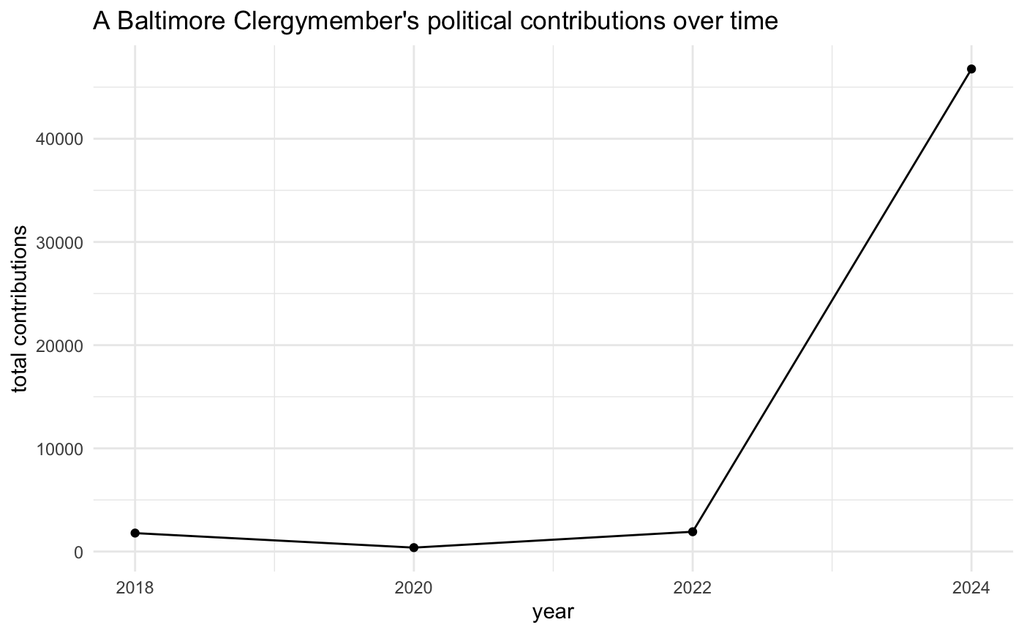

```r
cowan_contribs_aggregate |>
  ggplot() +
  geom_line(aes(x=two_year_transaction_period, y=total)) +
  geom_point(aes(x=two_year_transaction_period, y=total)) +
  theme_minimal() +
  labs(
    title="A Baltimore Clergymember's political contributions over time",
    x = "year",
    y = "total contributions"
  )
```

Question 2 –> Which cities in Maryland have the highest clergy contributions? Are they more urban, more affluent?

In this section of code, I created a dataframe looking at the top contributing cities within Maryland using the clergy combined contributions data. First, I grouped by contributor city, then summarized the total amount by contribution receipt amount then arranged the results by the total amount. Then I filtered the results to show those who have contributed over $1500.

```r
top_cities <- clergy_contribs_combined |>
  group_by(contributor_city) |>
  summarise(total_amount = sum(contribution_receipt_amount, na.rm = TRUE), total_contribs = n()) |>
  arrange(desc(total_amount)) |>
  mutate(contributor_city = trimws(contributor_city)) |>
  filter(total_amount > 1500.00)
top_cities
```

| contributor_city | total_amount | total_contribs |
| --- | --- | --- |
| BALTIMORE | 129293.71 | 10659 |
| SILVER SPRING | 84241.94 | 3698 |
| UPPER MARLBORO | 55530.68 | 540 |
| BOWIE | 43444.63 | 1131 |
| SEVERNA PARK | 35099.99 | 601 |
| ELLICOTT CITY | 35030.71 | 1115 |
| ROCKVILLE | 31960.65 | 785 |
| FORT WASHINGTON | 31015.06 | 623 |
| TOWSON | 24961.93 | 1401 |
| LAUREL | 24704.54 | 1087 |

[output cut: 83 more lines]

```r
NA
```

In order to join my database, I needed to clean up the top cities so that I could join them later with the Maryland census tract data in order to create a map. This included removing city from some of the names and anything else that was necessary. In this dataframe, there are 93 rows and 3 columns.

```r
write_csv(top_cities, "top_cities.csv")

top_cities <- read_csv("top_cities.csv")
```

## Getting Maryland Census data - median income and population

For this section, I created a dataframe of Maryland cities using the get_acs function to grab census tract data for each city based on median income level and population. In order to ensure both estimate columns were present in this dataframe, I used pivot wider to create the separate columns.

```r
md_cities <- get_acs(
  geography = "place",
  variables = c(
    median_income = "B19013_001",
    population = "B01003_001"
  ),
  year = 2021,
  state = "MD",
  geometry = TRUE
) |>
  select(NAME, variable, estimate, geometry) |>
  pivot_wider(
    names_from = variable,
    values_from = estimate
  )
```

#Cleaning md_cities

In this section of code, I cleaned up the md_cities dataframe using str_remove_all to remove all of the ,Maryland from the end of each city, then str_to_upper to capitalize all of the city names, then str_remove_all again to remove various titles from the city names, such as “town,” “city” and “village.” This step allows me to seamlessly combine the top cities dataframe with the Maryland cities in order to make comparisons.

```r
md_cities <- md_cities |>
  mutate(NAME = str_to_title(str_remove_all(NAME, ", Maryland"))) |>
  mutate(NAME = str_to_upper(NAME)) |>
  mutate(NAME = str_remove_all(NAME, " CDP")) |>
  mutate(NAME = str_remove_all(NAME, " TOWN")) |>
  mutate(NAME = str_remove_all(NAME, " CITY")) |>
  mutate(NAME = str_remove_all(NAME, " VILLAGE")) |>
  mutate(NAME = trimws(NAME))
```

##Combining the top cities dataframe with the md_cities_pop dataframe.

In the following section, I created a new dataframe which joined the md_cities dataframe to the top_cities dataframe, joining by the name of the city. For the next step, I wanted to find the contribution rate by population and by median income level - to do so, I used mutate and then arranged this data in descending order to see the top cities that contributed by their rates.

```r
md_city_contribs <- md_cities |>
  inner_join(top_cities, join_by(NAME == contributor_city)) |>
  mutate(contribs_rate_pop = total_amount/population*10000,
         contribs_rate_income = total_amount/median_income*10000) |>
  arrange(desc(contribs_rate_pop))

top_cities |>
  anti_join(md_cities, join_by(contributor_city == NAME))
```

| contributor_city | total_amount | total_contribs |
| --- | --- | --- |
| ELLICOTT CITY | 35030.71 | 1115 |
| LOTHIAN | 10250.00 | 4 |
| GWYNN OAK | 7036.65 | 171 |
| MARRIOTTSVILLE | 6705.81 | 249 |
| PORT REPUBLIC | 6250.59 | 333 |
| LUTHERVILLE TIMONIUM | 5254.60 | 68 |
| FINKSBURG | 4711.82 | 78 |
| MONTGOMERY VILLAGE | 3961.27 | 51 |
| NOTTINGHAM | 3245.60 | 97 |
| FORT WASHINGTOM | 2751.98 | 161 |

[output cut: 9 more lines]

```r
NA
```

##Making Maps

In the following code block, I created a map to display my results from the above sections. First, I got the every county within the US, then filtered that dataframe to find only the Maryland counties. This would allow me to have a Maryland outline for my map. Then, I created the map using ggplot and geom_sf, using the md_counties data for the outline, then the md_city_contribs as the actual data to pull from, and filled the cities by the contribution rate by population. I did the same steps for the contributions by median income level as well for a comparison of the two.

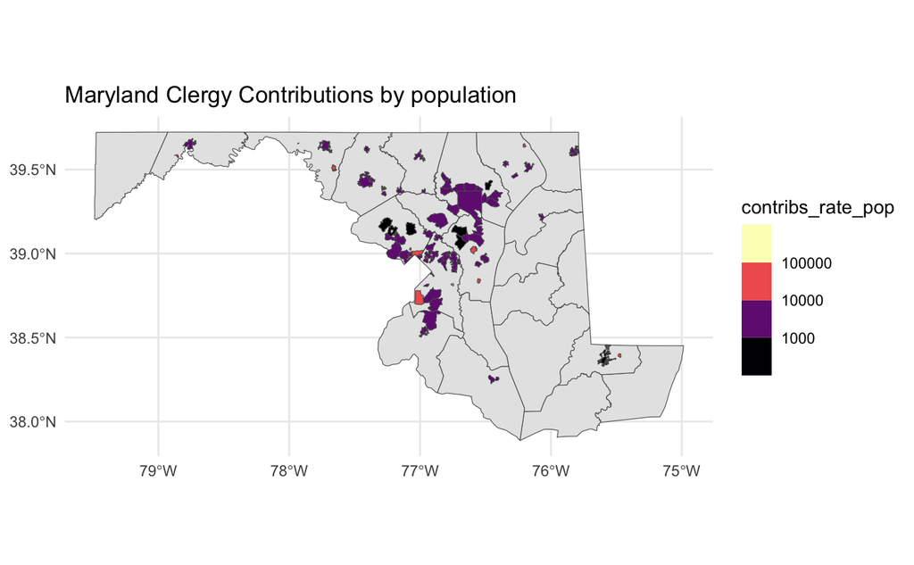

```r
counties <- counties()

md_counties <- counties |>
  filter(STATEFP == "24")


ggplot() +
  geom_sf(data=md_counties) +
  geom_sf(data=md_city_contribs, aes(fill=contribs_rate_pop)) +
  theme_minimal() +
  scale_fill_viridis_b(option="magma",trans = "log10") +
  labs(title = "Maryland Clergy Contributions by population")
```

The spatial distribution suggests clergy political giving is driven by concentrated donor activity rather than broad-based participation. Many of the political contributions are concentrated in the urban/suburban areas of Maryland, such as Prince George’s County, Montgomery County and Baltimore.

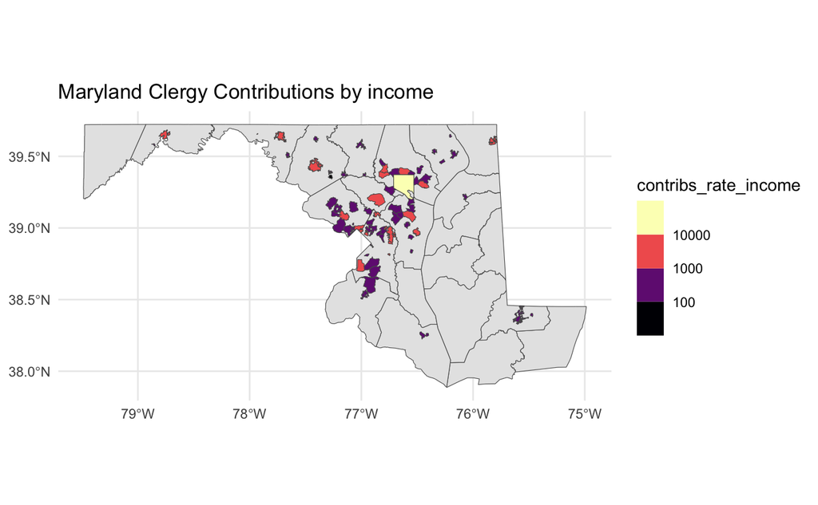

```r
counties <- counties()

md_counties <- counties |>
  filter(STATEFP == "24")


ggplot() +
  geom_sf(data=md_counties) +
  geom_sf(data=md_city_contribs, aes(fill=contribs_rate_income)) +
  theme_minimal() +
  scale_fill_viridis_b(option="magma",trans = "log10") +
  labs(title = "Maryland Clergy Contributions by income")
```

The highest contribution-to-income tract in Maryland corresponds to the residence area of the dataset’s largest clergy donor, Doris Cowan, suggesting that spatial variation in clergy political giving is driven in part by a small number of high-volume contributors.

#Memo

** Summary of results **

Across clergy donors identified in Maryland campaign finance data and federal clergy contributions from 2018–2024, an analysis of the clergy-related political contributions suggests that political giving is highly concentrated both geographically and individually.

Clergy contributions relative to median income are highly concentrated in urban areas, such as Baltimore exhibiting the highest contribution rate. Correspondingly, the top clergy member identified in the subset of clergy donors who contributed to federal and state campaigns resides in Baltimore, which could possibly skew the results of this analysis.

Doris Cowan, a retired clergy member from the Presbytery of Baltimore, has far outnumbered other top clergy members that were identified in both the clergy contributions data and Maryland campaign contributions data. On the federal level, this individual has contributed over 6,000 times and 25 times on the state level, donating exclusively to democratic committees and organizations. Compared to other clergy member contributions, Cowan is a clear outlier in the data in contribution frequency and the total amount of money contributed. This donor exhibits unusually high donation frequency, suggesting sustained and repeated political engagement over time in comparison to the other clergy members within the identified subset.

Another interesting factor is that many of the top clergy contributors are donating on the federal level, rather than the state level, and these contributions have increased over time with more contributions given during the 2024 election cycle compared to previous years. Additionally, I think there could be a story made here about the clergy contributors that donate to republican efforts, and how they combat the amount of donations given to the other side.

** Strengths and Limitations of my results and data**

# Strengths

I would say there are several strengths that can be identified within my data. The main strength is that my data are directly from state and federal political contribution records rather than self-reported data, eliminating the potential self-reporting bias. This allows me to achieve high data reliability. Since I have combined two dataframes to find my results, I would also say that this adds to the reliability of my results, in which the combined datasets allow me to identify overlapping contributors to analyze, rather than a simple analysis of the clergy contribution data. Beyond identifying the overlapping members in my subset, I also identified an outlier in my data.

** Next Steps **

To verify my results, I need to replicate my findings, following the same process I did in order to confirm these results are accurate and reliable. I think to check some of the patterns, such as the political contributions being concentrated in Baltimore, it would be best to replicate my steps using the top five clergy contributors and the top 25 clergy contributors. This would allow me to see if there is still an individual concentration of payments and whether there is still a trend of contributing to democratic committees. Then, it would be important to reach out directly to Doris Cowan to understand her political behavior and confirm that these payments are known and intentional. Additionally, I think it would be important to reach out to some of the committees to confirm receipt transactions, such as ACTBLUE that has received the bulk of donations from clergy members. Lastly, it would be important to speak with experts in campaign finance data, such as political scientists.